# IODS course project

# Week 6 - Analysis of longitudinal data

## Analysis

### Load needed packages and the data sets

```r
# Load packages
library(tidyverse)
library(ggplot2)
library(dplyr)
library(lme4)
# Load the data sets (they are in long format now)
rats <- read.csv("C:/Users/kveu/Work Folders/PhD Research/Courses/IODS/IODS-project/Data/rats.csv")
bprs <- read.csv("C:/Users/kveu/Work Folders/PhD Research/Courses/IODS/IODS-project/Data/bprs.csv")
```

```r
# Make sure the categorical variables are factors

bprs <- bprs %>%
  mutate(treatment = factor(treatment),
         subject = factor(subject))

rats <- rats %>%
  mutate(ID = factor(ID),
         Group = factor(Group))
```

### FIrst analysis using the RATS data set

The RATS data set comes from a nutrition study using rats; three groups of rats were put on different diets and their weights were measured approx. weekly except twice in week seven, for a total of nine weeks. The main question here is whether the growth profiles differ between the three groups.

For this analysis, we are going to ignore the fact that the repeated measures from the same rodents are most likely correlated with each other, and we are going to assume they all are independent.

```r
# Overview of the data

dim(rats)
```

```
## [1] 176   5
```

```r
str(rats)
```

```
## 'data.frame':    176 obs. of  5 variables:
##  $ ID    : Factor w/ 16 levels "1","2","3","4",..: 1 2 3 4 5 6 7 8 9 10 ...
##  $ Group : Factor w/ 3 levels "1","2","3": 1 1 1 1 1 1 1 1 2 2 ...
##  $ WD    : chr  "WD1" "WD1" "WD1" "WD1" ...
##  $ Weight: int  240 225 245 260 255 260 275 245 410 405 ...
##  $ time  : int  1 1 1 1 1 1 1 1 1 1 ...
```

```r
summary(rats)
```

```
##        ID      Group       WD                Weight           time
##  1      : 11   1:88   Length:176         Min.   :225.0   Min.   : 1.00
##  2      : 11   2:44   Class :character   1st Qu.:267.0   1st Qu.:15.00
##  3      : 11   3:44   Mode  :character   Median :344.5   Median :36.00
##  4      : 11                             Mean   :384.5   Mean   :33.55
##  5      : 11                             3rd Qu.:511.2   3rd Qu.:50.00
##  6      : 11                             Max.   :628.0   Max.   :64.00
##  (Other):110
```

The RATS data set has 176 observations and five variables: individual rat IDs, the (diet) Group they belong to, WD indicating the weight measurement day, Weight of the rats and time, which tells us the same measurement day as WD but it is in a form which can be used in analysis etc.

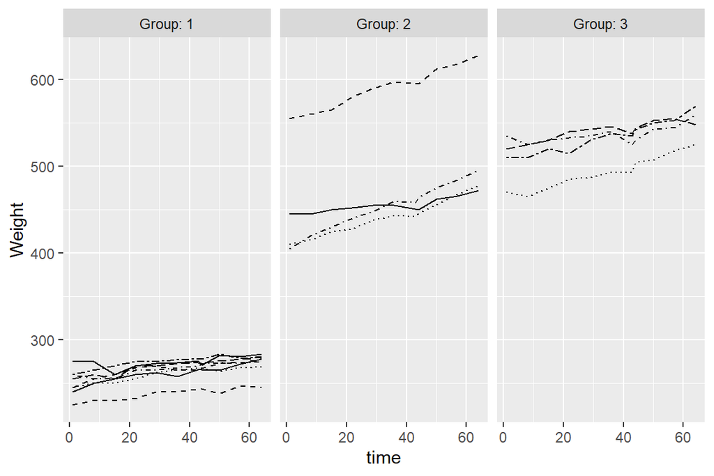

```r
# Graphical overview of the data

ggplot(rats, aes(x = time, y = Weight, linetype = ID)) +
  geom_line() +
  scale_linetype_manual(values = rep(1:10, times=4)) +
  facet_grid(. ~ Group, labeller = label_both) +
  theme(legend.position = "none") +
  scale_y_continuous(limits = c(min(rats$Weight), max(rats$Weight)))
```

In the plot above we have three graphs corresponding to the three diet groups. The lines represent the individual rats’ weights as a function of time. It seems that the weights increase with time; the increase is modest in Group 1 and there is less variability in that group compared to the other two groups. It also seems like the variability decreases with time, at least if we exclude some of the outliers. We can also clearly see that the starting weight varies a lot (especially between groups) and that the rats that have high weight at baseline have higher weights at the end of the study as well (phenomenon called as tracking). This would indicate that treating the rats and their weights as independent measurements is not a good idea, but for the sake of the example and assignment, we will continue with that approach. # We want to standardise according to the time point the measurements belong to

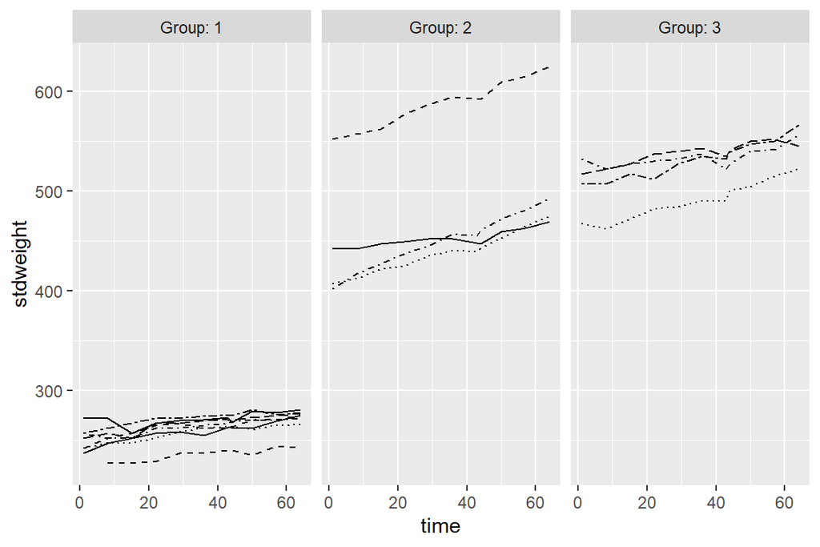

```r
# Let's standardise the weight variable to see the tracking effect more clearly

rats <- rats %>%
  group_by(time) %>%
  mutate(stdweight = (Weight - mean(Weight) / sd(Weight))) %>%
  ungroup()

# Plot the graph again using the standardised weights

ggplot(rats, aes(x = time, y = stdweight, linetype = ID)) +
  geom_line() +
  scale_linetype_manual(values = rep(1:10, times=4)) +
  facet_grid(. ~ Group, labeller = label_both) +
  theme(legend.position = "none") +
  scale_y_continuous(limits = c(min(rats$Weight), max(rats$Weight)))
```

To be honest, I do not see much difference compared to the original graph, although the tracking is still there.

Let’s make a tidier summary graph of the weights. There are 8 rats in group 1 and 4 in group 2 and 3, which has to be taken into account when calculating SEs.

```r
# Create a new data set with summarised mean and standard error of the weights by group and time

ratss <- rats %>%
  group_by(Group, time) %>%
  summarise(mean = mean(Weight),
            se = sd(Weight)) %>%
  ungroup()
```

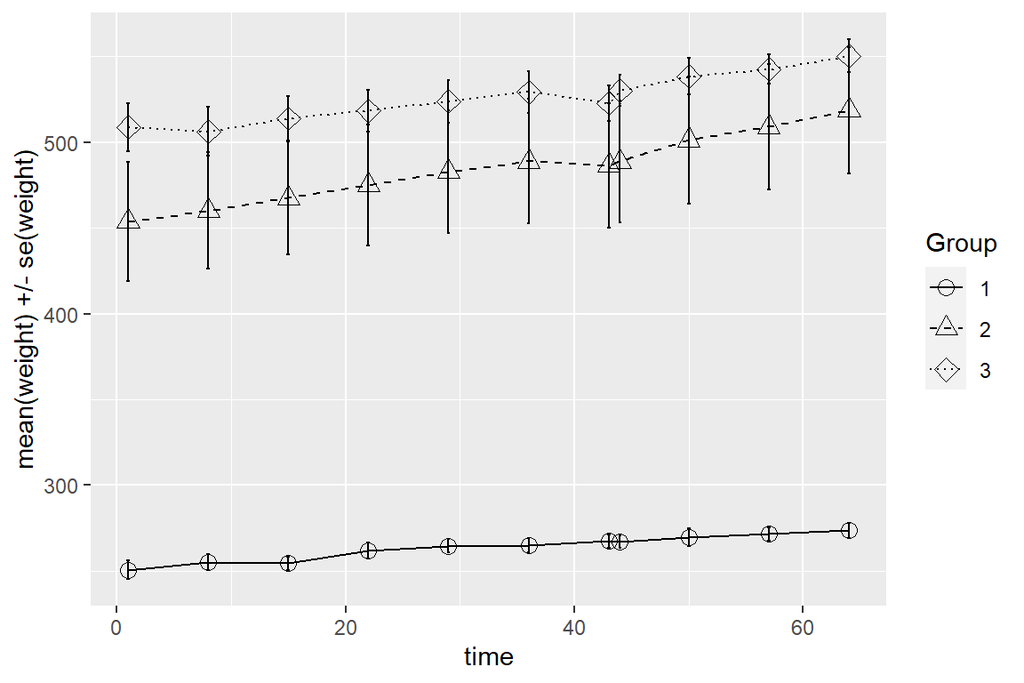

```r
ratss <- ratss %>%
  mutate(se = ifelse(Group==1,se/sqrt(8),se/sqrt(4))) # somehow I didn't get the ifelse structure to work in the first function so had to do it separately

# Plot the mean profiles

ggplot(ratss, aes(x = time, y = mean, linetype = Group, shape = Group)) +
  geom_line() +
  scale_linetype_manual(values = c(1,2,3)) +
  geom_point(size=3) +
  scale_shape_manual(values = c(1,2,5)) +
  geom_errorbar(aes(ymin=mean-se, ymax=mean+se, linetype="1"), width=0.3) +
  #theme(legend.position = c(1,0.8)) +
  scale_y_continuous(name = "mean(weight) +/- se(weight)")
```

From the graph above we can see that there seems to be significant differences between the growth profiles between group 1 and the two other groups. The starting weight of groups 2 and 3 could be significantly different, but at later time points the SEs overlap so there probably will not be significant differences.

It seems like the mean weight in group 1 increases by approx. 25g, while it increases by approx. 70g in group 2 and 50g in group 3 (between start and end of the study period).

Now let’s get rid of the outliers

```r
# Creating summary data
ratss2 <- rats %>%
  filter(time > 1) %>%
  group_by(Group, ID) %>%
  summarise( mean=mean(Weight) ) %>%
  ungroup()
```

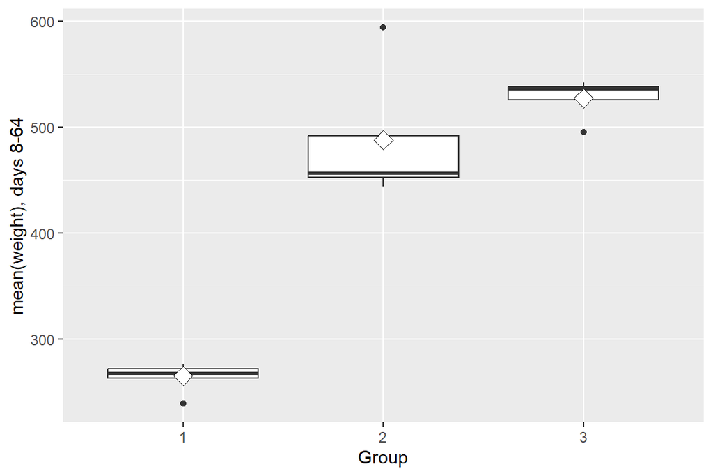

```r
# Draw a boxplot of the mean versus group

ggplot(ratss2, aes(x = Group, y = mean)) +
  geom_boxplot() +
  stat_summary(fun = "mean", geom = "point", shape=23, size=4, fill = "white") +
  scale_y_continuous(name = "mean(weight), days 8-64")
```

Here we can identify the outliers in the groups that could cause bias, so let’s remove them before furter analyses.

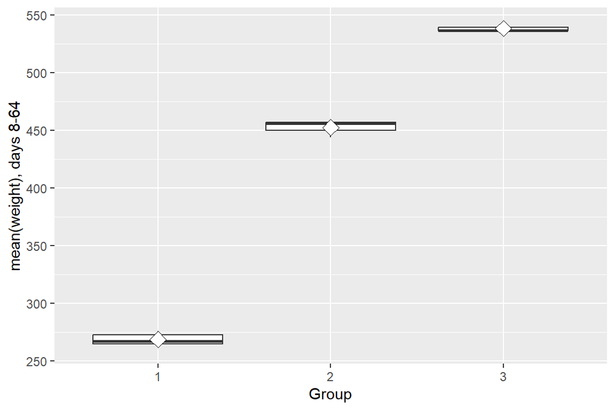

```r
# Filter out the outliers

# Filter the "easy" outliers
ratss2 <- ratss2 %>%
  filter(mean > 250 & mean < 550)

# Filter the outlier in Group 3
ratss2 <- ratss2 %>%
  filter(!(Group==3 & mean<500))


# Plot again
ggplot(ratss2, aes(x = Group, y = mean)) +
  geom_boxplot() +
  stat_summary(fun = "mean", geom = "point", shape=23, size=4, fill = "white") +
  scale_y_continuous(name = "mean(weight), days 8-64")
```

The summary measures seem to be quite different from each other between groups. However, as we saw earlier, the baseline weights were so different that they alone could produce these errors instead of the diets (even though we excluded baseline values from this plot).

However, we will still assume independence and perform statistical tests. We have three groups to compare, so t-test is not the way to go here. We will use ANOVA to see if the groups are statistically different.

```r
# Perform t-test between each group

anova_result <- aov(mean ~ Group, data = ratss2)
summary(anova_result)
```

```
##             Df Sum Sq Mean Sq F value   Pr(>F)
## Group        2 176917   88458    2836 1.69e-14 ***
## Residuals   10    312      31
## ---
## Signif. codes:  0 '***' 0.001 '**' 0.01 '*' 0.05 '.' 0.1 ' ' 1
```

There is indeed a significant difference between the groups, as is indicated by the p-value (1.69e-14). However, we don’t know which groups are different from each other. For this reason, we will perform a posthoc test.

```r
# Perform the posthoc test
library(rstatix)
posthoc <- ratss2 %>%
  tukey_hsd(mean~Group)

posthoc
```

```
## # A tibble: 3 × 9
##   term  group1 group2 null.value estimate conf.low conf.high    p.adj
## * <chr> <chr>  <chr>       <dbl>    <dbl>    <dbl>     <dbl>    <dbl>
## 1 Group 1      2               0    184.     173.      194.  2.09e-12
## 2 Group 1      3               0    270.     259.      280.  3.31e-14
## 3 Group 2      3               0     85.9     73.4      98.4 1.10e- 8
## # ℹ 1 more variable: p.adj.signif <chr>
```

As can be seen from the posthoc table, all the groups are significantly different from each other.

Baseline values are usually correlated with summary measures and thus we would be more likely to see differences, so it will probably not make a difference here so we will not go into it.